### scotch whiskies flavour mapping with MDS

```
library(dplyr)
library(ggplot2)
library(gridExtra)

dplyr：資料操控工具包
ggplot2：繪圖及空間可視化
gridExtra：繪圖排列功能套件
```

上次使用了 PCA(Principal Component Analysis) 方法產生 whiskies flavour map，然而，MDS (Multidimensional Scaling) 也可以幫助了解資料集的結構，將多維變數轉成二維，繪出 observations 的相對距離。同樣使用 whisky.groups 資料集，共86筆，18個變數欄位，包括流水編號(RowID)、蒸餾廠名稱(Distillery)、威士忌風味(3至14欄:Body, Sweetness, Smoky, Medicinal, Tobacco, Honey, Spicy, Winey, Nutty, Malty, Fruity, Floral)、郵遞區號(Postcode)、緯度(Latitude)、經度(Longitude)及群集編號(Groups)

```
## 'data.frame':    86 obs. of  18 variables:
##  $ RowID     : int  1 2 3 4 5 6 7 8 9 10 ...
##  $ Distillery: chr  "Aberfeldy" "Aberlour" "AnCnoc" "Ardbeg" ...
##  $ Body      : int  2 3 1 4 2 2 0 2 2 2 ...
##  $ Sweetness : int  2 3 3 1 2 3 2 3 2 3 ...
##  $ Smoky     : int  2 1 2 4 2 1 0 1 1 2 ...
##  $ Medicinal : int  0 0 0 4 0 1 0 0 0 1 ...
##  $ Tobacco   : int  0 0 0 0 0 0 0 0 0 0 ...
##  $ Honey     : int  2 4 2 0 1 1 1 2 1 0 ...
##  $ Spicy     : int  1 3 0 2 1 1 1 1 0 2 ...
##  $ Winey     : int  2 2 0 0 1 1 0 2 0 0 ...
##  $ Nutty     : int  2 2 2 1 2 0 2 2 2 2 ...
##  $ Malty     : int  2 3 2 2 3 1 2 2 2 1 ...
##  $ Fruity    : int  2 3 3 1 1 1 3 2 2 2 ...
##  $ Floral    : int  2 2 2 0 1 2 3 1 2 1 ...
##  $ Postcode  : chr  "PH152EB" "AB389PJ" "AB55LI" "PA427EB" ...
##  $ Latitude  : num  56.6 57.5 57.6 55.6 57.4 ...
##  $ Longitude : num  -3.85 -3.23 -2.76 -6.11 -2.74 ...
##  $ Groups    : Factor w/ 3 levels "1","2","3": 2 2 1 3 1 1 1 2 1 1 ...
```

先從 whisky.groups 取出威士忌風味(3至14欄)，用 Distillery 命名rownames、轉成matrix (86 * 12)，前10筆資料如下

|  | Body | Sweetness | Smoky | Medicinal | Tobacco | Honey | Spicy | Winey | Nutty | Malty | Fruity | Floral |
| --- | --- | --- | --- | --- | --- | --- | --- | --- | --- | --- | --- | --- |
| Aberfeldy | 2 | 2 | 2 | 0 | 0 | 2 | 1 | 2 | 2 | 2 | 2 | 2 |
| Aberlour | 3 | 3 | 1 | 0 | 0 | 4 | 3 | 2 | 2 | 3 | 3 | 2 |
| AnCnoc | 1 | 3 | 2 | 0 | 0 | 2 | 0 | 0 | 2 | 2 | 3 | 2 |
| Ardbeg | 4 | 1 | 4 | 4 | 0 | 0 | 2 | 0 | 1 | 2 | 1 | 0 |
| Ardmore | 2 | 2 | 2 | 0 | 0 | 1 | 1 | 1 | 2 | 3 | 1 | 1 |
| ArranIsleOf | 2 | 3 | 1 | 1 | 0 | 1 | 1 | 1 | 0 | 1 | 1 | 2 |
| Auchentoshan | 0 | 2 | 0 | 0 | 0 | 1 | 1 | 0 | 2 | 2 | 3 | 3 |
| Auchroisk | 2 | 3 | 1 | 0 | 0 | 2 | 1 | 2 | 2 | 2 | 2 | 1 |
| Aultmore | 2 | 2 | 1 | 0 | 0 | 1 | 0 | 0 | 2 | 2 | 2 | 2 |
| Balblair | 2 | 3 | 2 | 1 | 0 | 0 | 2 | 0 | 2 | 1 | 2 | 1 |

透過矩陣乘積，產生 whisky.MP 的matrix，再利用 dist 轉換成距離，接著使用預設 stats 套件中的 cmdscale 來完成 MDS。查看 whisky.MDS 前10筆資料可發現，已經變成 86 * 2 的matrix

```r
# matrix product
whisky.MP <- whisky.mtx %*% t(whisky.mtx)
# dist
whisky.dist <- dist(whisky.MP)
# mds
whisky.MDS <- cmdscale(whisky.dist)
head(whisky.MDS, 10)
```

```
##                      [,1]        [,2]
## Aberfeldy     -30.3557735  -5.7372269
## Aberlour     -141.5873203 -15.3861641
## AnCnoc        -14.0129899 -17.6323917
## Ardbeg          0.5590346  74.3961676
## Ardmore         8.0307800   2.8405487
## ArranIsleOf    42.6515272  -0.6109913
## Auchentoshan   38.1371734 -36.8521517
## Auchroisk     -22.0882362 -10.1630150
## Aultmore       29.9349445 -11.7896874
## Balblair        9.2877704  12.8583822
```

確認資料一致性後，新增對應的 Groups 欄位並轉成 data frame，接著使用 ggplot 繪圖

```r
identical(rownames(whisky.MDS), whisky.groups$Distillery)
```

```
## [1] TRUE
```

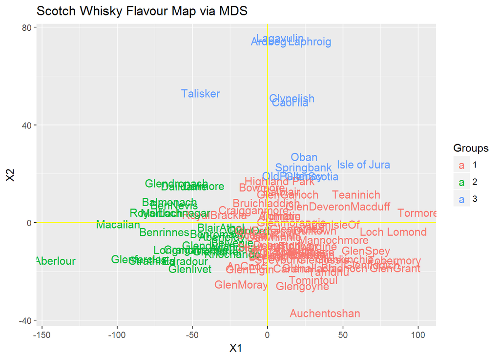

```r
# add Groups col. and transfer to df.
whisky.MDS <- transform(whisky.MDS, Groups = whisky.groups$Groups)
ggplot(whisky.MDS, aes(x=X1, y=X2, colour=Groups)) +
  geom_text(aes(label=rownames(whisky.MDS)), size=4) +
  ggtitle("Scotch Whisky Flavour Map via MDS") +
  geom_hline(yintercept = 0, color ='yellow') +
  geom_vline(xintercept = 0, color ='yellow')
```

為了方便與 PCA 的結果相比較，將 MDS 的 X1, X2 對調再繪製，發現兩者的結果在某程度上是雷同的，事實上，PCA 可視為最基本的 MDS 解法。雖然透過 MDS 可以快速將多維資料以2維方式展現(12個維度變成2個)，但透過 PCA 能了解命名定義 X, Y 軸屬性…

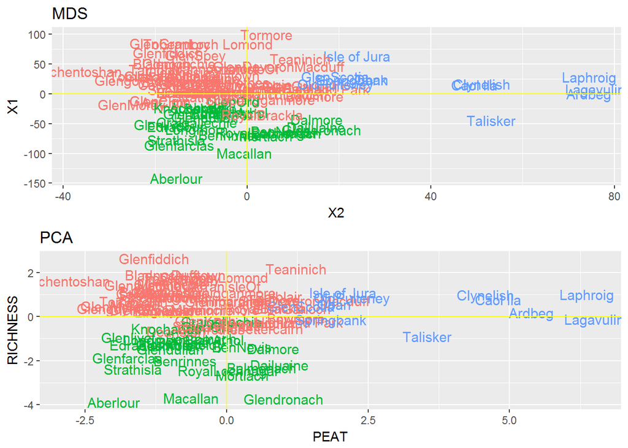

### Lessons Learned:

#### Multidimensional Scaling (MDS).